# Twitter_US_airline_sentiment

```python
# install and import necessary libraries.

!pip install contractions

import re, string, unicodedata
import contractions
from bs4 import BeautifulSoup

import numpy as np
import pandas as pd
import nltk

nltk.download('stopwords')
nltk.download('punkt')
nltk.download('wordnet')

from nltk.corpus import stopwords
from nltk.tokenize import word_tokenize, sent_tokenize
from nltk.stem.wordnet import WordNetLemmatizer
```

```python
from google.colab import drive
```

```python
drive.mount('/content/drive/')
```

```python
project_path = '/content/drive/My Drive/Colab Notebooks/'
```

```python
dataset_file = project_path + 'Tweets.csv'
```

```python
#Load dataset

data = pd.read_csv(dataset_file)
```

```python
data.head() # we can see many Nan values on the dataset
```

|  | tweet_id | airline_sentiment | airline_sentiment_confidence | negativereason | negativereason_confidence | airline | airline_sentiment_gold | name | negativereason_gold | retweet_count | text | tweet_coord | tweet_created | tweet_location | user_timezone |
| --- | --- | --- | --- | --- | --- | --- | --- | --- | --- | --- | --- | --- | --- | --- | --- |
| 0 | 570306133677760513 | neutral | 1.0000 | NaN | NaN | Virgin America | NaN | cairdin | NaN | 0 | @VirginAmerica What @dhepburn said. | NaN | 2015-02-24 11:35:52 -0800 | NaN | Eastern Time (US & Canada) |
| 1 | 570301130888122368 | positive | 0.3486 | NaN | 0.0000 | Virgin America | NaN | jnardino | NaN | 0 | @VirginAmerica plus you've added commercials to the experience... tacky. | NaN | 2015-02-24 11:15:59 -0800 | NaN | Pacific Time (US & Canada) |
| 2 | 570301083672813571 | neutral | 0.6837 | NaN | NaN | Virgin America | NaN | yvonnalynn | NaN | 0 | @VirginAmerica I didn't today... Must mean I need to take another trip! | NaN | 2015-02-24 11:15:48 -0800 | Lets Play | Central Time (US & Canada) |
| 3 | 570301031407624196 | negative | 1.0000 | Bad Flight | 0.7033 | Virgin America | NaN | jnardino | NaN | 0 | @VirginAmerica it's really aggressive to blast obnoxious "entertainment" in your guests' faces &amp; they have little recourse | NaN | 2015-02-24 11:15:36 -0800 | NaN | Pacific Time (US & Canada) |
| 4 | 570300817074462722 | negative | 1.0000 | Can't Tell | 1.0000 | Virgin America | NaN | jnardino | NaN | 0 | @VirginAmerica and it's a really big bad thing about it | NaN | 2015-02-24 11:14:45 -0800 | NaN | Pacific Time (US & Canada) |

```python
data.shape # prints number of rows and columns
```

```
(14640, 15)
```

```python
data.isna().sum() # the data has many null values as well
```

```
tweet_id                            0
airline_sentiment                   0
airline_sentiment_confidence        0
negativereason                   5462
negativereason_confidence        4118
airline                             0
airline_sentiment_gold          14600
name                                0
negativereason_gold             14608
retweet_count                       0
text                                0
tweet_coord                     13621
tweet_created                       0
tweet_location                   4733
user_timezone                    4820
dtype: int64
```

```python
data.info()
```

```
<class 'pandas.core.frame.DataFrame'>
RangeIndex: 14640 entries, 0 to 14639
Data columns (total 15 columns):
 #   Column                        Non-Null Count  Dtype
---  ------                        --------------  -----
 0   tweet_id                      14640 non-null  int64
 1   airline_sentiment             14640 non-null  object
 2   airline_sentiment_confidence  14640 non-null  float64
 3   negativereason                9178 non-null   object
 4   negativereason_confidence     10522 non-null  float64
 5   airline                       14640 non-null  object
 6   airline_sentiment_gold        40 non-null     object
 7   name                          14640 non-null  object
 8   negativereason_gold           32 non-null     object
 9   retweet_count                 14640 non-null  int64
 10  text                          14640 non-null  object
 11  tweet_coord                   1019 non-null   object
 12  tweet_created                 14640 non-null  object
 13  tweet_location                9907 non-null   object
 14  user_timezone                 9820 non-null   object
dtypes: float64(2), int64(2), object(11)
memory usage: 1.7+ MB
```

```python
# we are not doing null value processing here as we are going to drop all columns except airline sentiment and text

dataset=data.drop(['tweet_id','airline_sentiment_confidence','negativereason','negativereason_confidence','airline','airline_sentiment_gold','name','negativereason_gold','retweet_count','tweet_coord','tweet_created','tweet_location','user_timezone'],axis=1)
```

```python
dataset.shape # prints shape of new dataset
```

```
(14640, 2)
```

```python
dataset.head() # prints first five rows of dataset
```

|  | airline_sentiment | text |
| --- | --- | --- |
| 0 | neutral | @VirginAmerica What @dhepburn said. |
| 1 | positive | @VirginAmerica plus you've added commercials to the experience... tacky. |
| 2 | neutral | @VirginAmerica I didn't today... Must mean I need to take another trip! |
| 3 | negative | @VirginAmerica it's really aggressive to blast obnoxious "entertainment" in your guests' faces &amp; they have little recourse |
| 4 | negative | @VirginAmerica and it's a really big bad thing about it |

```python
pd.set_option('display.max_colwidth', None) # Display full dataframe information

dataset.head()
```

|  | airline_sentiment | text |
| --- | --- | --- |
| 0 | neutral | @VirginAmerica What @dhepburn said. |
| 1 | positive | @VirginAmerica plus you've added commercials to the experience... tacky. |
| 2 | neutral | @VirginAmerica I didn't today... Must mean I need to take another trip! |
| 3 | negative | @VirginAmerica it's really aggressive to blast obnoxious "entertainment" in your guests' faces &amp; they have little recourse |
| 4 | negative | @VirginAmerica and it's a really big bad thing about it |

```python
dataset.isna().sum() # there are no null values
```

```
airline_sentiment    0
text                 0
dtype: int64
```

```python
# Text Preprocessing

# HTML tag removal

def strip_html(text):
    soup = BeautifulSoup(text, "html.parser")
    return soup.get_text()

dataset['text'] = dataset['text'].apply(lambda x: strip_html(x))
dataset.head()
```

|  | airline_sentiment | text |
| --- | --- | --- |
| 0 | neutral | @VirginAmerica What @dhepburn said. |
| 1 | positive | @VirginAmerica plus you've added commercials to the experience... tacky. |
| 2 | neutral | @VirginAmerica I didn't today... Must mean I need to take another trip! |
| 3 | negative | @VirginAmerica it's really aggressive to blast obnoxious "entertainment" in your guests' faces & they have little recourse |
| 4 | negative | @VirginAmerica and it's a really big bad thing about it |

```python
# Replace contractions in text


def replace_contractions(text):
    """Replace contractions in string of text"""
    return contractions.fix(text)

dataset['text'] = dataset['text'].apply(lambda x: replace_contractions(x))
dataset.head()
```

|  | airline_sentiment | text |
| --- | --- | --- |
| 0 | neutral | @VirginAmerica What @dhepburn said. |
| 1 | positive | @VirginAmerica plus you have added commercials to the experience... tacky. |
| 2 | neutral | @VirginAmerica I did not today... Must mean I need to take another trip! |
| 3 | negative | @VirginAmerica it is really aggressive to blast obnoxious "entertainment" in your guests' faces & they have little recourse |
| 4 | negative | @VirginAmerica and it is a really big bad thing about it |

```python
# Tokenize the words of whole dataframe.
for i, row in dataset.iterrows():
    text = dataset.at[i, 'text']
    words = nltk.word_tokenize(text)
    dataset.at[i,'text'] = words
dataset.head()
```

|  | airline_sentiment | text |
| --- | --- | --- |
| 0 | neutral | [@, VirginAmerica, What, @, dhepburn, said, .] |
| 1 | positive | [@, VirginAmerica, plus, you, have, added, commercials, to, the, experience, ..., tacky, .] |
| 2 | neutral | [@, VirginAmerica, I, did, not, today, ..., Must, mean, I, need, to, take, another, trip, !] |
| 3 | negative | [@, VirginAmerica, it, is, really, aggressive, to, blast, obnoxious, ``, entertainment, '', in, your, guests, ', faces, &, they, have, little, recourse] |
| 4 | negative | [@, VirginAmerica, and, it, is, a, really, big, bad, thing, about, it] |

```python
# Remove numbers

def remove_numbers(words):
    """Remove all numbers from list of tokenized words"""
    new_words = []
    for word in words:
        new_word = re.sub(r'\d+', '' , word)
        new_words.append(new_word)
    return new_words

dataset['text'] = dataset['text'].apply(lambda x: remove_numbers(x))
dataset.head()
```

|  | airline_sentiment | text |
| --- | --- | --- |
| 0 | neutral | [@, VirginAmerica, What, @, dhepburn, said, .] |
| 1 | positive | [@, VirginAmerica, plus, you, have, added, commercials, to, the, experience, ..., tacky, .] |
| 2 | neutral | [@, VirginAmerica, I, did, not, today, ..., Must, mean, I, need, to, take, another, trip, !] |
| 3 | negative | [@, VirginAmerica, it, is, really, aggressive, to, blast, obnoxious, ``, entertainment, '', in, your, guests, ', faces, &, they, have, little, recourse] |
| 4 | negative | [@, VirginAmerica, and, it, is, a, really, big, bad, thing, about, it] |

```python
# Remove special characters

def remove_special_characters(words):
    """Remove all special characters from list of tokenized words"""
    new_words = []
    for word in words:
        new_word = re.sub(r'[^a-zA-z\s]', '' , word)
        new_words.append(new_word)
    return new_words

dataset['text'] = dataset['text'].apply(lambda x: remove_special_characters(x))
dataset.head()
```

|  | airline_sentiment | text |
| --- | --- | --- |
| 0 | neutral | [, VirginAmerica, What, , dhepburn, said, ] |
| 1 | positive | [, VirginAmerica, plus, you, have, added, commercials, to, the, experience, , tacky, ] |
| 2 | neutral | [, VirginAmerica, I, did, not, today, , Must, mean, I, need, to, take, another, trip, ] |
| 3 | negative | [, VirginAmerica, it, is, really, aggressive, to, blast, obnoxious, ``, entertainment, , in, your, guests, , faces, , they, have, little, recourse] |
| 4 | negative | [, VirginAmerica, and, it, is, a, really, big, bad, thing, about, it] |

```python
# Remove punctuation

def remove_punctuation(words):
    """Remove all special characters from list of tokenized words"""
    new_words = []
    for word in words:
        new_word = re.sub(r'[^\w\s]', '' , word)
        new_words.append(new_word)
    return new_words

dataset['text'] = dataset['text'].apply(lambda x: remove_punctuation(x))
dataset.head()
```

|  | airline_sentiment | text |
| --- | --- | --- |
| 0 | neutral | [, VirginAmerica, What, , dhepburn, said, ] |
| 1 | positive | [, VirginAmerica, plus, you, have, added, commercials, to, the, experience, , tacky, ] |
| 2 | neutral | [, VirginAmerica, I, did, not, today, , Must, mean, I, need, to, take, another, trip, ] |
| 3 | negative | [, VirginAmerica, it, is, really, aggressive, to, blast, obnoxious, , entertainment, , in, your, guests, , faces, , they, have, little, recourse] |
| 4 | negative | [, VirginAmerica, and, it, is, a, really, big, bad, thing, about, it] |

```python
# Convert to lowercase

def to_lowercase(words):
    """Convert all characters to lowercase from list of tokenized words"""
    new_words = []
    for word in words:
        new_word = word.lower()
        new_words.append(new_word)
    return new_words

dataset['text'] = dataset['text'].apply(lambda x: to_lowercase(x))
dataset.head()
```

|  | airline_sentiment | text |
| --- | --- | --- |
| 0 | neutral | [, virginamerica, what, , dhepburn, said, ] |
| 1 | positive | [, virginamerica, plus, you, have, added, commercials, to, the, experience, , tacky, ] |
| 2 | neutral | [, virginamerica, i, did, not, today, , must, mean, i, need, to, take, another, trip, ] |
| 3 | negative | [, virginamerica, it, is, really, aggressive, to, blast, obnoxious, , entertainment, , in, your, guests, , faces, , they, have, little, recourse] |
| 4 | negative | [, virginamerica, and, it, is, a, really, big, bad, thing, about, it] |

```python
# Lemmatize

lemmatizer= WordNetLemmatizer()

def lemmatize_list(words):
    new_words = []
    for word in words:
      new_words.append(lemmatizer.lemmatize(word, pos='v'))
    return ' '.join(new_words)


dataset['text'] = dataset['text'].apply(lambda x: lemmatize_list(x))
dataset.head()
```

|  | airline_sentiment | text |
| --- | --- | --- |
| 0 | neutral | virginamerica what dhepburn say |
| 1 | positive | virginamerica plus you have add commercials to the experience tacky |
| 2 | neutral | virginamerica i do not today must mean i need to take another trip |
| 3 | negative | virginamerica it be really aggressive to blast obnoxious entertainment in your guests face they have little recourse |
| 4 | negative | virginamerica and it be a really big bad thing about it |

```python
dataset.head () # data after text preprocessing - first five rows
```

|  | airline_sentiment | text |
| --- | --- | --- |
| 0 | neutral | virginamerica what dhepburn say |
| 1 | positive | virginamerica plus you have add commercials to the experience tacky |
| 2 | neutral | virginamerica i do not today must mean i need to take another trip |
| 3 | negative | virginamerica it be really aggressive to blast obnoxious entertainment in your guests face they have little recourse |
| 4 | negative | virginamerica and it be a really big bad thing about it |

```python
# Count Vectorizer

from sklearn.feature_extraction.text import CountVectorizer

vectorizer = CountVectorizer(max_features=1000)                # Keep only 1000 features as number of features will increase the processing time.
data_features = vectorizer.fit_transform(dataset['text'])

data_features = data_features.toarray()
```

```python
data_features.shape
```

```
(14640, 1000)
```

```python
dataset['airline_sentiment'].value_counts()
```

```
negative    9178
neutral     3099
positive    2363
Name: airline_sentiment, dtype: int64
```

```python
# we need one hot encoding here to convert object to int

dataset=dataset.replace(to_replace={'airline_sentiment': {'negative': 0,'neutral':1,'positive':2}})
```

```python
dataset['airline_sentiment'].value_counts()
```

```
0    9178
1    3099
2    2363
Name: airline_sentiment, dtype: int64
```

```python
labels = dataset['airline_sentiment']
labels = labels.astype('int')
```

```python
# Split data into training and testing set.

from sklearn.model_selection import train_test_split

X_train, X_test, y_train, y_test = train_test_split(data_features, labels, test_size=0.3, random_state=42)
```

```python
# Using Random Forest to build model for the classification of reviews.
# Also calculating the cross validation score.

from sklearn.ensemble import RandomForestClassifier
from sklearn.model_selection import cross_val_score

forest = RandomForestClassifier(n_estimators=10, n_jobs=4)

forest = forest.fit(X_train, y_train)

print(forest)

print(np.mean(cross_val_score(forest, data_features, labels, cv=10)))
```

```
RandomForestClassifier(bootstrap=True, ccp_alpha=0.0, class_weight=None,
                       criterion='gini', max_depth=None, max_features='auto',
                       max_leaf_nodes=None, max_samples=None,
                       min_impurity_decrease=0.0, min_impurity_split=None,
                       min_samples_leaf=1, min_samples_split=2,
                       min_weight_fraction_leaf=0.0, n_estimators=10, n_jobs=4,
                       oob_score=False, random_state=None, verbose=0,
                       warm_start=False)
0.7133879781420764
```

```python
# Predict the result for test data using the model built above.

result = forest.predict(X_test)
```

```
[[2628  140   46]
 [ 453  372   59]
 [ 231  119  344]]
```

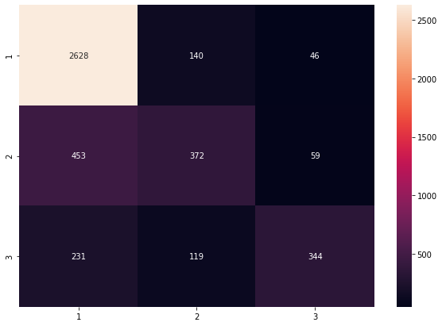

```python
# Print and plot Confusion matirx to get an idea of how the distribution of the prediction is, among all the classes.

import matplotlib.pyplot as plt
import seaborn as sns
from sklearn.metrics import confusion_matrix

conf_mat = confusion_matrix(y_test, result)

print(conf_mat)

df_cm = pd.DataFrame(conf_mat, index = [i for i in "123"],
                  columns = [i for i in "123"])
plt.figure(figsize = (10,7))
sns.heatmap(df_cm, annot=True, fmt='g')
```

```python
from sklearn.metrics import classification_report # Classification report
print(classification_report(y_test,result))
```

```
              precision    recall  f1-score   support

           0       0.79      0.93      0.86      2814
           1       0.59      0.42      0.49       884
           2       0.77      0.50      0.60       694

    accuracy                           0.76      4392
   macro avg       0.72      0.62      0.65      4392
weighted avg       0.75      0.76      0.74      4392
```

```python
# TD-IDF Vectorization


from sklearn.feature_extraction.text import TfidfVectorizer

vectorizer = TfidfVectorizer(max_features=1000)
data_features = vectorizer.fit_transform(dataset['text'])

data_features = data_features.toarray()

data_features.shape
```

```
(14640, 1000)
```

```python
# Using Random Forest to build model for the classification of reviews.
# Also calculating the cross validation score.

from sklearn.ensemble import RandomForestClassifier
from sklearn.model_selection import cross_val_score

import numpy as np

forest = RandomForestClassifier(n_estimators=10, n_jobs=4)

forest = forest.fit(X_train, y_train)

print(forest)

print(np.mean(cross_val_score(forest, data_features, labels, cv=10)))
```

```
RandomForestClassifier(bootstrap=True, ccp_alpha=0.0, class_weight=None,
                       criterion='gini', max_depth=None, max_features='auto',
                       max_leaf_nodes=None, max_samples=None,
                       min_impurity_decrease=0.0, min_impurity_split=None,
                       min_samples_leaf=1, min_samples_split=2,
                       min_weight_fraction_leaf=0.0, n_estimators=10, n_jobs=4,
                       oob_score=False, random_state=None, verbose=0,
                       warm_start=False)
0.7177595628415301
```

```python
result1 = forest.predict(X_test)
```

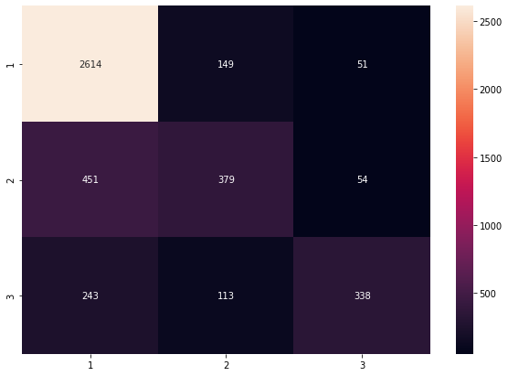

```python
import matplotlib.pyplot as plt
import seaborn as sns
from sklearn.metrics import confusion_matrix

conf_mat = confusion_matrix(y_test, result1)

df_cm = pd.DataFrame(conf_mat, index = [i for i in "123"],
                  columns = [i for i in "123"])
plt.figure(figsize = (10,7))
sns.heatmap(df_cm, annot=True, fmt='g')
```

```python
from sklearn.metrics import classification_report # Classification report
print(classification_report(y_test,result1))
```

```
              precision    recall  f1-score   support

           0       0.79      0.93      0.85      2814
           1       0.59      0.43      0.50       884
           2       0.76      0.49      0.59       694

    accuracy                           0.76      4392
   macro avg       0.71      0.61      0.65      4392
weighted avg       0.75      0.76      0.74      4392
```

Summary :

Machine Learning always needs data in numeric form , so we use encoding techniques to convert text to numbers But we need some cleanup of text data before encoding

To preprocess the text , below steps were taken in this project

1.HTML tag Removal - there is no valuable information from these tags so we are removing it

2.Replace Contractions - There are certain words that has an apostrophe eg; you've - we can expand this so that there wont be two different words for 'you have' and 'you've'

3.Tokenization - it breaks raw text into words so that we dont need a full sentence to understand the context

4.Remove numbers - our project is not going to get information from numbers

5.Remove special characters - these simply adds noise to the text , so we are removing it

6.Remove punctuation - For our model punctuation has no important role so we are removing it , we are doing it after tokenization and replacing contractions so that it doenst the program by any means

7.Convert to lowercase - we convert all text to lowercase so the words are not treated different due to case

8.Lemmatize - Trims the suffix and match it to root words , I prefer lemmatize to stemming so that I can get a meaningful word always

9.Join words - Converting the tokenized form to a string

After performing above steps the text is clean and we used both Countvectoriser and TD-IDF vectoriser to convert these to a form that our ML model can understand

TF-IDF - same as count vectorization , but words are multiplied by IDF to feature numerically

The last step is to make predictions on the model. To do so, we need to call the predict method on the object of the RandomForestClassifier class that we used for training.

Using cros_val-score as metric , both the models are approx 71% and there is no much difference -a little improvement is seen with Tf-IDF

We also used confusion matrix to evaluate the performance of our model